# Project2_02

A.S

October 7, 2016

## **Annual US Population Estimates**

##### **The dataset for this project is downloaded from https://www.census.gov/popest/data/datasets.html. This is the annual estimates of the resident population by single year of age and gender for the United States for 04/01/2010 to 07/01/2015.**

##### **The objective of this project is to analyze the population data and how it changes for each gender and age group:**

##### **The following dplyr/tidyr functions are used in this project**

| **dplyr** | **tidyr** |
| --- | --- |
| **mutate** | **gather** |
| **filter** | **spread** |
| **arrange** | **separate** |

##### **(1) Save the data as a CSV file:**

```r
library(tidyr)
library(dplyr)
library(stringr)
library(sqldf)
```

```r
library(ggplot2)
```

##### **(2) Read the information from the .CSV file into R, and use tidyr and dplyr as needed to tidy and transform your data:**

##### **(2.a) Read *02_USPopulationEstimate.csv* file**

```r
populationEstimate_df = read.csv(file="02_USPopulationEstimate.csv", header=TRUE, sep=",")
head(populationEstimate_df, 5)
```

```
##   SEX AGE CENSUS2010POP ESTIMATESBASE2010 POPESTIMATE2010 POPESTIMATE2011 POPESTIMATE2012 POPESTIMATE2013 POPESTIMATE2014 POPESTIMATE2015
## 1   0   0       3944153           3944160         3951330         3963087         3926540         3931141         3949775         3978038
## 2   0   1       3978070           3978090         3957888         3966551         3977939         3942872         3949776         3968564
## 3   0   2       4096929           4096939         4090862         3971565         3980095         3992720         3959664         3966583
## 4   0   3       4119040           4119051         4111920         4102470         3983157         3992734         4007079         3974061
## 5   0   4       4063170           4063186         4077551         4122294         4112849         3994449         4005716         4020035
```

```r
print(colnames(populationEstimate_df))
```

```
##  [1] "SEX"               "AGE"               "CENSUS2010POP"     "ESTIMATESBASE2010" "POPESTIMATE2010"   "POPESTIMATE2011"   "POPESTIMATE2012"   "POPESTIMATE2013"   "POPESTIMATE2014"   "POPESTIMATE2015"
```

##### **(2.b) Apply tidyr *gather* function to change the data format from wide to long and change column names.**

```r
populationEstimate2_df = gather(populationEstimate_df, TYPE, POPULATION, CENSUS2010POP:POPESTIMATE2015)
colnames(populationEstimate2_df) = c("Gender", "Age", "Type", "Population")
```

##### **(2.c) Replace numbers with words to represent gender. In the original data “0” means Total, “1” means Males and “2” means Females.**

```r
populationEstimate2_df$Gender[populationEstimate2_df$Gender=="0"] = "Total"
populationEstimate2_df$Gender[populationEstimate2_df$Gender=="1"] = "Male"
populationEstimate2_df$Gender[populationEstimate2_df$Gender=="2"] = "Female"
head(populationEstimate2_df, 10)
```

```
##    Gender Age          Type Population
## 1   Total   0 CENSUS2010POP    3944153
## 2   Total   1 CENSUS2010POP    3978070
## 3   Total   2 CENSUS2010POP    4096929
## 4   Total   3 CENSUS2010POP    4119040
## 5   Total   4 CENSUS2010POP    4063170
## 6   Total   5 CENSUS2010POP    4056858
## 7   Total   6 CENSUS2010POP    4066381
## 8   Total   7 CENSUS2010POP    4030579
## 9   Total   8 CENSUS2010POP    4046486
## 10  Total   9 CENSUS2010POP    4148353
```

##### **(2.d) Perform data manipulation to extract appropriate data contents. Then apply tidyr *separate* function to split the date column from Type column.**

```r
populationEstimate2_df$Type = gsub("CENSUS", "CENSUS_", populationEstimate2_df$Type)
populationEstimate2_df$Type = gsub("POP", "", populationEstimate2_df$Type)
populationEstimate2_df$Type = gsub("ESTIMATESBASE", "BASEESTIMATE", populationEstimate2_df$Type)
populationEstimate2_df$Type = gsub("ESTIMATE", "ESTIMATE_", populationEstimate2_df$Type)
populationEstimate2_df = separate(populationEstimate2_df, Type, c("Type", "Year"), sep = "_")
populationEstimate2_df$Type = gsub("BASEESTIMATE", "BASE_ESTIMATE", populationEstimate2_df$Type)
head(populationEstimate2_df, 10)
```

```
##    Gender Age   Type Year Population
## 1   Total   0 CENSUS 2010    3944153
## 2   Total   1 CENSUS 2010    3978070
## 3   Total   2 CENSUS 2010    4096929
## 4   Total   3 CENSUS 2010    4119040
## 5   Total   4 CENSUS 2010    4063170
## 6   Total   5 CENSUS 2010    4056858
## 7   Total   6 CENSUS 2010    4066381
## 8   Total   7 CENSUS 2010    4030579
## 9   Total   8 CENSUS 2010    4046486
## 10  Total   9 CENSUS 2010    4148353
```

##### **(2.e) Apply dplyr *arrange* function and to sort the data on Gender**

```r
populationEstimate2_df = arrange(populationEstimate2_df, Gender)
head(populationEstimate2_df, 10)
```

```
##    Gender Age   Type Year Population
## 1  Female   0 CENSUS 2010    1929877
## 2  Female   1 CENSUS 2010    1947217
## 3  Female   2 CENSUS 2010    2004731
## 4  Female   3 CENSUS 2010    2014490
## 5  Female   4 CENSUS 2010    1985620
## 6  Female   5 CENSUS 2010    1984764
## 7  Female   6 CENSUS 2010    1991062
## 8  Female   7 CENSUS 2010    1973503
## 9  Female   8 CENSUS 2010    1981033
## 10 Female   9 CENSUS 2010    2028657
```

```r
populationEstimate3_df = spread(populationEstimate2_df, Gender, Population)
head(populationEstimate3_df, 10)
```

```
##    Age          Type Year  Female    Male   Total
## 1    0 BASE_ESTIMATE 2010 1929882 2014278 3944160
## 2    0        CENSUS 2010 1929877 2014276 3944153
## 3    0      ESTIMATE 2010 1932910 2018420 3951330
## 4    0      ESTIMATE 2011 1934660 2028427 3963087
## 5    0      ESTIMATE 2012 1918823 2007717 3926540
## 6    0      ESTIMATE 2013 1921613 2009528 3931141
## 7    0      ESTIMATE 2014 1929449 2020326 3949775
## 8    0      ESTIMATE 2015 1942904 2035134 3978038
## 9    1 BASE_ESTIMATE 2010 1947229 2030861 3978090
## 10   1        CENSUS 2010 1947217 2030853 3978070
```

##### **(2.g) Create a function to calculate the percentage and round it to 2 decimal digits**

```r
calcPercentage = function(value, totalValue) {
  round((value/totalValue)*100, 2)
}
```

```r
populationEstimate3_df = mutate(populationEstimate3_df, PercentFemale=calcPercentage(Female, Total), PercentMale=calcPercentage(Male, Total))
head(populationEstimate3_df, 10)
```

```
##    Age          Type Year  Female    Male   Total PercentFemale PercentMale
## 1    0 BASE_ESTIMATE 2010 1929882 2014278 3944160         48.93       51.07
## 2    0        CENSUS 2010 1929877 2014276 3944153         48.93       51.07
## 3    0      ESTIMATE 2010 1932910 2018420 3951330         48.92       51.08
## 4    0      ESTIMATE 2011 1934660 2028427 3963087         48.82       51.18
## 5    0      ESTIMATE 2012 1918823 2007717 3926540         48.87       51.13
## 6    0      ESTIMATE 2013 1921613 2009528 3931141         48.88       51.12
## 7    0      ESTIMATE 2014 1929449 2020326 3949775         48.85       51.15
## 8    0      ESTIMATE 2015 1942904 2035134 3978038         48.84       51.16
## 9    1 BASE_ESTIMATE 2010 1947229 2030861 3978090         48.95       51.05
## 10   1        CENSUS 2010 1947217 2030853 3978070         48.95       51.05
```

##### **(3) Prepare data for analysis:**

##### **(3.a) Apply dplyr *filter* function to get Census data and display Age vs % of males**

```r
graph_df2 = filter (populationEstimate3_df, (Type == "CENSUS" & Age != 999))
head(graph_df2, 10)
```

```
##    Age   Type Year  Female    Male   Total PercentFemale PercentMale
## 1    0 CENSUS 2010 1929877 2014276 3944153         48.93       51.07
## 2    1 CENSUS 2010 1947217 2030853 3978070         48.95       51.05
## 3    2 CENSUS 2010 2004731 2092198 4096929         48.93       51.07
## 4    3 CENSUS 2010 2014490 2104550 4119040         48.91       51.09
## 5    4 CENSUS 2010 1985620 2077550 4063170         48.87       51.13
## 6    5 CENSUS 2010 1984764 2072094 4056858         48.92       51.08
## 7    6 CENSUS 2010 1991062 2075319 4066381         48.96       51.04
## 8    7 CENSUS 2010 1973503 2057076 4030579         48.96       51.04
## 9    8 CENSUS 2010 1981033 2065453 4046486         48.96       51.04
## 10   9 CENSUS 2010 2028657 2119696 4148353         48.90       51.10
```

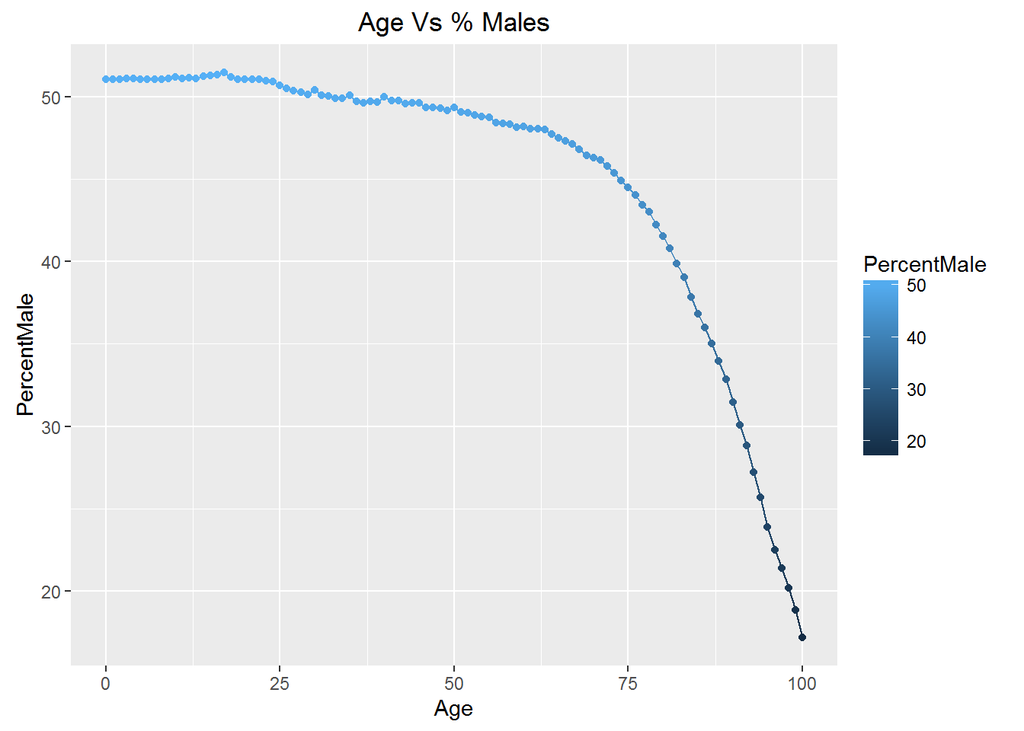

```r
ggplot(data=graph_df2, aes(x=Age, y=PercentMale, color=PercentMale)) +  geom_line() +
  geom_point() + ylab("PercentMale") +  ggtitle("Age Vs % Males")
```

##### **(3.b) Apply dplyr *filter* function to get Census data for all genders and display Age vs males and female population**

```r
# Question: Draw Males and Females in a chat and see the difference
graph_df0 = filter (populationEstimate2_df, (Type == "CENSUS" & Age != 999 & Gender != "Total"))
head(graph_df0, 10)
```

```
##    Gender Age   Type Year Population
## 1  Female   0 CENSUS 2010    1929877
## 2  Female   1 CENSUS 2010    1947217
## 3  Female   2 CENSUS 2010    2004731
## 4  Female   3 CENSUS 2010    2014490
## 5  Female   4 CENSUS 2010    1985620
## 6  Female   5 CENSUS 2010    1984764
## 7  Female   6 CENSUS 2010    1991062
## 8  Female   7 CENSUS 2010    1973503
## 9  Female   8 CENSUS 2010    1981033
## 10 Female   9 CENSUS 2010    2028657
```

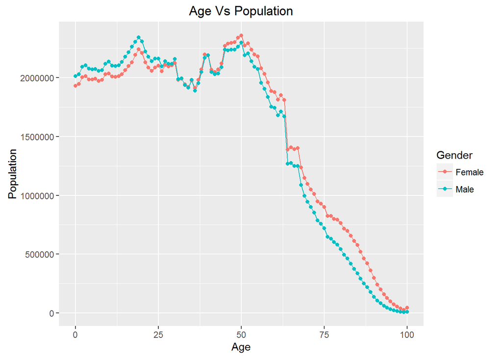

```r
ggplot(data=graph_df0, aes(x=Age, y=Population, group=Gender, color=Gender)) +  geom_line() +
  geom_point() + ylab("Population") +  ggtitle("Age Vs Population")
```